# Communicate Data Findings:February 2019 Ford GoBike TourData Exploration

## Introduction

This project's dataset comprises 183412 cases of trips from place to place about the SanFrancisco Bay Area, inclusive of tour duration, start and end time of tours for February 2019

## Preliminary Wrangling

```python
# import all packages and set plots to be embedded inline
import numpy as np
import pandas as pd
import matplotlib.pyplot as plt
import seaborn as sb

%matplotlib inline

import warnings
warnings.filterwarnings('ignore')
```

```python
# load in the dataset into pandas dataframe
fordgo_bike = pd.read_csv('fordgobike-tripdata-201902.csv')
```

```python
# display original dataset information
fordgo_bike.info()
```

```
<class 'pandas.core.frame.DataFrame'>
RangeIndex: 183412 entries, 0 to 183411
Data columns (total 16 columns):
 #   Column                   Non-Null Count   Dtype
---  ------                   --------------   -----
 0   duration_sec             183412 non-null  int64
 1   start_time               183412 non-null  object
 2   end_time                 183412 non-null  object
 3   start_station_id         183215 non-null  float64
 4   start_station_name       183215 non-null  object
 5   start_station_latitude   183412 non-null  float64
 6   start_station_longitude  183412 non-null  float64
 7   end_station_id           183215 non-null  float64
 8   end_station_name         183215 non-null  object
 9   end_station_latitude     183412 non-null  float64
 10  end_station_longitude    183412 non-null  float64
 11  bike_id                  183412 non-null  int64
 12  user_type                183412 non-null  object
 13  member_birth_year        175147 non-null  float64
 14  member_gender            175147 non-null  object
 15  bike_share_for_all_trip  183412 non-null  object
dtypes: float64(7), int64(2), object(7)
memory usage: 22.4+ MB
```

## Assessment

Assessing visually </br>

```python
fordgo_bike.shape
```

```
(183412, 16)
```

```python
fordgo_bike.head(15)
```

|  | duration_sec | start_time | end_time | start_station_id | start_station_name | start_station_latitude | start_station_longitude | end_station_id | end_station_name | end_station_latitude | end_station_longitude | bike_id | user_type | member_birth_year | member_gender | bike_share_for_all_trip |
| --- | --- | --- | --- | --- | --- | --- | --- | --- | --- | --- | --- | --- | --- | --- | --- | --- |
| 0 | 52185 | 2019-02-28 17:32:10.1450 | 2019-03-01 08:01:55.9750 | 21.0 | Montgomery St BART Station (Market St at 2nd St) | 37.789625 | -122.400811 | 13.0 | Commercial St at Montgomery St | 37.794231 | -122.402923 | 4902 | Customer | 1984.0 | Male | No |
| 1 | 42521 | 2019-02-28 18:53:21.7890 | 2019-03-01 06:42:03.0560 | 23.0 | The Embarcadero at Steuart St | 37.791464 | -122.391034 | 81.0 | Berry St at 4th St | 37.775880 | -122.393170 | 2535 | Customer | NaN | NaN | No |
| 2 | 61854 | 2019-02-28 12:13:13.2180 | 2019-03-01 05:24:08.1460 | 86.0 | Market St at Dolores St | 37.769305 | -122.426826 | 3.0 | Powell St BART Station (Market St at 4th St) | 37.786375 | -122.404904 | 5905 | Customer | 1972.0 | Male | No |
| 3 | 36490 | 2019-02-28 17:54:26.0100 | 2019-03-01 04:02:36.8420 | 375.0 | Grove St at Masonic Ave | 37.774836 | -122.446546 | 70.0 | Central Ave at Fell St | 37.773311 | -122.444293 | 6638 | Subscriber | 1989.0 | Other | No |
| 4 | 1585 | 2019-02-28 23:54:18.5490 | 2019-03-01 00:20:44.0740 | 7.0 | Frank H Ogawa Plaza | 37.804562 | -122.271738 | 222.0 | 10th Ave at E 15th St | 37.792714 | -122.248780 | 4898 | Subscriber | 1974.0 | Male | Yes |
| 5 | 1793 | 2019-02-28 23:49:58.6320 | 2019-03-01 00:19:51.7600 | 93.0 | 4th St at Mission Bay Blvd S | 37.770407 | -122.391198 | 323.0 | Broadway at Kearny | 37.798014 | -122.405950 | 5200 | Subscriber | 1959.0 | Male | No |
| 6 | 1147 | 2019-02-28 23:55:35.1040 | 2019-03-01 00:14:42.5880 | 300.0 | Palm St at Willow St | 37.317298 | -121.884995 | 312.0 | San Jose Diridon Station | 37.329732 | -121.901782 | 3803 | Subscriber | 1983.0 | Female | No |
| 7 | 1615 | 2019-02-28 23:41:06.7660 | 2019-03-01 00:08:02.7560 | 10.0 | Washington St at Kearny St | 37.795393 | -122.404770 | 127.0 | Valencia St at 21st St | 37.756708 | -122.421025 | 6329 | Subscriber | 1989.0 | Male | No |
| 8 | 1570 | 2019-02-28 23:41:48.7900 | 2019-03-01 00:07:59.7150 | 10.0 | Washington St at Kearny St | 37.795393 | -122.404770 | 127.0 | Valencia St at 21st St | 37.756708 | -122.421025 | 6548 | Subscriber | 1988.0 | Other | No |
| 9 | 1049 | 2019-02-28 23:49:47.6990 | 2019-03-01 00:07:17.0250 | 19.0 | Post St at Kearny St | 37.788975 | -122.403452 | 121.0 | Mission Playground | 37.759210 | -122.421339 | 6488 | Subscriber | 1992.0 | Male | No |
| 10 | 458 | 2019-02-28 23:57:57.2110 | 2019-03-01 00:05:35.4350 | 370.0 | Jones St at Post St | 37.787327 | -122.413278 | 43.0 | San Francisco Public Library (Grove St at Hyde... | 37.778768 | -122.415929 | 5318 | Subscriber | 1996.0 | Female | Yes |
| 11 | 506 | 2019-02-28 23:56:55.5400 | 2019-03-01 00:05:21.7330 | 44.0 | Civic Center/UN Plaza BART Station (Market St ... | 37.781074 | -122.411738 | 343.0 | Bryant St at 2nd St | 37.783172 | -122.393572 | 5848 | Subscriber | 1993.0 | Male | No |
| 12 | 1176 | 2019-02-28 23:45:12.6510 | 2019-03-01 00:04:49.1840 | 127.0 | Valencia St at 21st St | 37.756708 | -122.421025 | 323.0 | Broadway at Kearny | 37.798014 | -122.405950 | 5328 | Customer | 1990.0 | Male | No |
| 13 | 915 | 2019-02-28 23:49:06.0620 | 2019-03-01 00:04:21.8670 | 252.0 | Channing Way at Shattuck Ave | 37.865847 | -122.267443 | 244.0 | Shattuck Ave at Hearst Ave | 37.873676 | -122.268487 | 5101 | Subscriber | NaN | NaN | No |
| 14 | 395 | 2019-02-28 23:56:26.8480 | 2019-03-01 00:03:01.9470 | 243.0 | Bancroft Way at College Ave | 37.869360 | -122.254337 | 252.0 | Channing Way at Shattuck Ave | 37.865847 | -122.267443 | 4786 | Subscriber | 1988.0 | Male | No |

```python
fordgo_bike.info()
```

```
<class 'pandas.core.frame.DataFrame'>
RangeIndex: 183412 entries, 0 to 183411
Data columns (total 16 columns):
 #   Column                   Non-Null Count   Dtype
---  ------                   --------------   -----
 0   duration_sec             183412 non-null  int64
 1   start_time               183412 non-null  object
 2   end_time                 183412 non-null  object
 3   start_station_id         183215 non-null  float64
 4   start_station_name       183215 non-null  object
 5   start_station_latitude   183412 non-null  float64
 6   start_station_longitude  183412 non-null  float64
 7   end_station_id           183215 non-null  float64
 8   end_station_name         183215 non-null  object
 9   end_station_latitude     183412 non-null  float64
 10  end_station_longitude    183412 non-null  float64
 11  bike_id                  183412 non-null  int64
 12  user_type                183412 non-null  object
 13  member_birth_year        175147 non-null  float64
 14  member_gender            175147 non-null  object
 15  bike_share_for_all_trip  183412 non-null  object
dtypes: float64(7), int64(2), object(7)
memory usage: 22.4+ MB
```

```python
fordgo_bike.isnull().sum()
```

```
duration_sec                  0
start_time                    0
end_time                      0
start_station_id            197
start_station_name          197
start_station_latitude        0
start_station_longitude       0
end_station_id              197
end_station_name            197
end_station_latitude          0
end_station_longitude         0
bike_id                       0
user_type                     0
member_birth_year          8265
member_gender              8265
bike_share_for_all_trip       0
dtype: int64
```

```python
fordgo_bike.duplicated().sum()
```

```
0
```

## Data Assessing and Cleaning

#### 1 .Drop null values in start_station_id,start_station_name,end_station_id,end_station_name,member_birth_year,member_gender

#### 2 .Convert Datatype of member_birth_year from float to int

#### 3 .Change start_time and end_time from object to datetime

#### 4 .Change to categorical variable user_type,member_gender,bike_share_share_for_all_trip

#### 5 .Create new column for day of the week and time of the day

#### 6 .Convert Datatype of duration_sec from integer to minutes

#### 7 .Convert member_birth_year to user year

```python
df_fordgobike = fordgo_bike.copy()
```

```python
# drop null values in 1 above
df_fordgobike.dropna(inplace=True)
```

```python
# test for null
df_fordgobike.isnull().sum()
```

```
duration_sec               0
start_time                 0
end_time                   0
start_station_id           0
start_station_name         0
start_station_latitude     0
start_station_longitude    0
end_station_id             0
end_station_name           0
end_station_latitude       0
end_station_longitude      0
bike_id                    0
user_type                  0
member_birth_year          0
member_gender              0
bike_share_for_all_trip    0
dtype: int64
```

```python
# generate function to test Dtype
def test_type(x):
    for var in x:
        print(f'{var} ----> {df_fordgobike[var].dtype}')
```

```python
# convert usertype,member_gender,bike_share_for_all_trip to categorical type
cass =['user_type', 'member_gender', 'bike_share_for_all_trip']
for var in cass:
    df_fordgobike[var]=df_fordgobike[var].astype('category')
```

```python
# conversion test
test_type(cass)
```

```
user_type ----> category
member_gender ----> category
bike_share_for_all_trip ----> category
```

```python
# convert to datetime format start_time and end_time
cass =['start_time', 'end_time']
for var in cass:
    df_fordgobike[var]=pd.to_datetime(df_fordgobike[var])
```

```python
# test convertion
test_type(cass)
```

```
start_time ----> datetime64[ns]
end_time ----> datetime64[ns]
```

```python
# change birth year to integer
df_fordgobike.member_birth_year=df_fordgobike.member_birth_year.astype('int')
```

```python
# remove and save in new column am and pm
df_fordgobike['time_of_day']=pd.to_datetime(df_fordgobike.start_time).dt.strftime('%p')
```

```python
# test column
df_fordgobike.time_of_day
```

```
0         PM
2         PM
3         PM
4         PM
5         PM
          ..
183407    AM
183408    AM
183409    AM
183410    AM
183411    AM
Name: time_of_day, Length: 174952, dtype: object
```

```python
# remove day of the week to 'day_of_week' column
df_fordgobike['day_of_week']=pd.to_datetime(df_fordgobike.start_time).dt.strftime('%A')
```

```python
# test column
df_fordgobike.day_of_week
```

```
0         Thursday
2         Thursday
3         Thursday
4         Thursday
5         Thursday
            ...
183407      Friday
183408      Friday
183409      Friday
183410      Friday
183411      Friday
Name: day_of_week, Length: 174952, dtype: object
```

```python
# rename duration_sec to duration_min
def renameColumn(old_name,new_name):
    df_fordgobike.rename(columns={old_name:new_name},inplace=True)
# convert column name
renameColumn('duration_sec','duration_min')
df_fordgobike.duration_min=df_fordgobike.duration_min/60
```

```python
# test convertion
df_fordgobike.duration_min
```

```
0          869.750000
2         1030.900000
3          608.166667
4           26.416667
5           29.883333
             ...
183407       8.000000
183408       5.216667
183409       2.350000
183410       2.316667
183411       4.516667
Name: duration_min, Length: 174952, dtype: float64
```

```python
# retitle member_birth_year to user_age
renameColumn('member_birth_year','user_age')
# change birth_year to age
df_fordgobike.user_age=df_fordgobike.start_time.dt.year - df_fordgobike.user_age
```

### Exploratory Data Analysis

```python
# display information about clean dataset
df_fordgobike.info()
```

```
<class 'pandas.core.frame.DataFrame'>
Int64Index: 174952 entries, 0 to 183411
Data columns (total 18 columns):
 #   Column                   Non-Null Count   Dtype
---  ------                   --------------   -----
 0   duration_min             174952 non-null  float64
 1   start_time               174952 non-null  datetime64[ns]
 2   end_time                 174952 non-null  datetime64[ns]
 3   start_station_id         174952 non-null  float64
 4   start_station_name       174952 non-null  object
 5   start_station_latitude   174952 non-null  float64
 6   start_station_longitude  174952 non-null  float64
 7   end_station_id           174952 non-null  float64
 8   end_station_name         174952 non-null  object
 9   end_station_latitude     174952 non-null  float64
 10  end_station_longitude    174952 non-null  float64
 11  bike_id                  174952 non-null  int64
 12  user_type                174952 non-null  category
 13  user_age                 174952 non-null  int64
 14  member_gender            174952 non-null  category
 15  bike_share_for_all_trip  174952 non-null  category
 16  time_of_day              174952 non-null  object
 17  day_of_week              174952 non-null  object
dtypes: category(3), datetime64[ns](2), float64(7), int64(2), object(4)
memory usage: 21.9+ MB
```

```python
# Numeric variable descriptive statistics
df_fordgobike.describe()
```

|  | duration_min | start_station_id | start_station_latitude | start_station_longitude | end_station_id | end_station_latitude | end_station_longitude | bike_id | user_age |
| --- | --- | --- | --- | --- | --- | --- | --- | --- | --- |
| count | 174952.000000 | 174952.000000 | 174952.000000 | 174952.000000 | 174952.000000 | 174952.000000 | 174952.000000 | 174952.000000 | 174952.000000 |
| mean | 11.733379 | 139.002126 | 37.771220 | -122.351760 | 136.604486 | 37.771414 | -122.351335 | 4482.587555 | 34.196865 |
| std | 27.370082 | 111.648819 | 0.100391 | 0.117732 | 111.335635 | 0.100295 | 0.117294 | 1659.195937 | 10.118731 |
| min | 1.016667 | 3.000000 | 37.317298 | -122.453704 | 3.000000 | 37.317298 | -122.453704 | 11.000000 | 18.000000 |
| 25% | 5.383333 | 47.000000 | 37.770407 | -122.411901 | 44.000000 | 37.770407 | -122.411647 | 3799.000000 | 27.000000 |
| 50% | 8.500000 | 104.000000 | 37.780760 | -122.398279 | 101.000000 | 37.781010 | -122.397437 | 4960.000000 | 32.000000 |
| 75% | 13.150000 | 239.000000 | 37.797320 | -122.283093 | 238.000000 | 37.797673 | -122.286533 | 5505.000000 | 39.000000 |
| max | 1409.133333 | 398.000000 | 37.880222 | -121.874119 | 398.000000 | 37.880222 | -121.874119 | 6645.000000 | 141.000000 |

### What is the structure of your dataset?

The dataset contains 174952 observations with 18 features(member_gender,bike_share_for_all,user_type,duration_min,station_id, and many others).

### What is/are the main feature(s) of interest in your dataset?

. What time spent in making use of service is of utmost interest to me and the category of users that make use of the tours the most. This will enable the Fordgobike company to know the category that generates revenue the most and to tailor their services to involve a broader category of people

. I am most interested in finding out what destination the user of this services use the most

### What features in the dataset do you think will help support your investigation into your feature(s) of interest?

i. member_gender

ii. bike_share_for_all_trip

iii. user_type

iv. duration_min

v. end_station_id

## Univariate Exploration

### Question

What is the shape of duration_min?

### Visualization

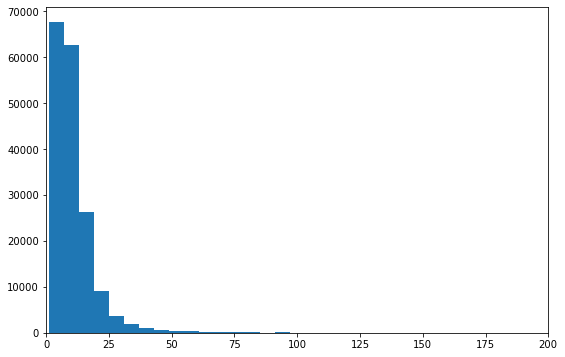

```python
# code for plotting
def plot_hist(data,size,var,log_plot=False):
    if log_plot:
        plt.figure(figsize=[9,6]);
        bins=10**np.arange(np.log10(data['duration_min'].min()),np.log10(data['duration_min'].max())+size,size)
        plt.hist(data=data,x=var,bins=bins);
        plt.xscale('log');

    else:
        plt.figure(figsize=[9,6]);
        bins=np.arange(data[var].min(),data[var].max()+size,size)
        plt.hist(data=data,x=var,bins=bins);

# plot graph
plot_hist(df_fordgobike,6,'duration_min',log_plot=False);
plt.xlim(0,200);
```

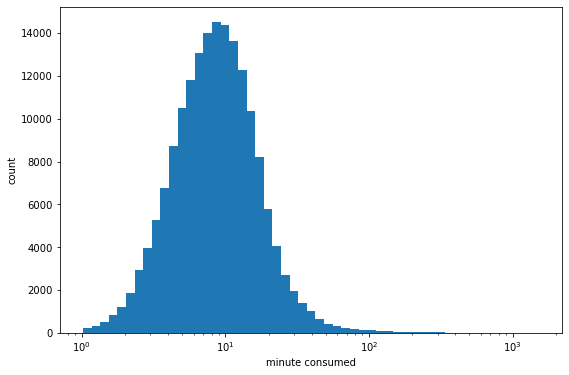

```python
# log scal plotting
plot_hist(df_fordgobike,0.06,'duration_min',log_plot=True)
plt.xlabel('minute consumed');
plt.ylabel('count');
plt.show();
```

## observation

The log plot depects linear distribution of the histogram is right skewed implying that the duration_min feature is unimodal

## Question

Which stations do people go the most

## Visualization

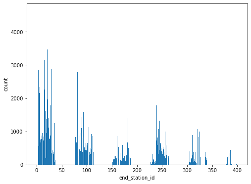

```python
plt.figure(figsize=[8,6])
bins=np.arange(0,df_fordgobike.end_station_id.max()+3,0.5)
plt.hist(data=df_fordgobike,x='end_station_id',bins=bins);
plt.xlabel('end_station_id');
plt.ylabel('count');
plt.show();
```

## Observation

Analysing the user destinations feature shows the highest traffic destination with id about

. 3-35 (Power St BART Station(Market St at 4th St)-Cahil Park)

. 75-120(Market St at Franklin St-Mission Dolores Park)

. 175(49th St at Telegraph Ave)

. 250(North Berkeley BART Station)

## QUESTION

What is the age spreading?

## visualization

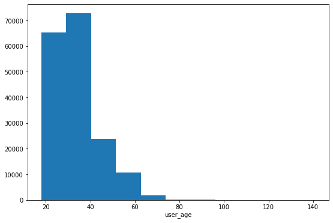

```python
 plt.figure(figsize=[9,6]);
size=(df_fordgobike.user_age.max() - df_fordgobike.user_age.min())/11
bins=np.arange(df_fordgobike.user_age.min(),df_fordgobike.user_age.max()+2,size)
plt.hist(data=df_fordgobike,x='user_age',bins=bins);
plt.xlabel('user_age');
```

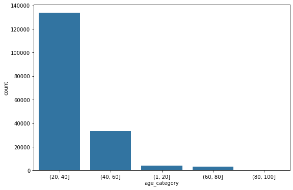

```python
# generate age_category column for explicit spreading
df_fordgobike['age_category']=pd.cut(x=df_fordgobike['user_age'],bins=[1,20,40,60,80,100])
# test each bin frequency
order=df_fordgobike['age_category'].value_counts().index
color=sb.color_palette()[0]
# graph plotting
plt.figure(figsize=[9,6]);
sb.countplot(data=df_fordgobike,x='age_category',color=color,order=order);
plt.show();
```

## Question

What is the spreading for user_type

## Visualization

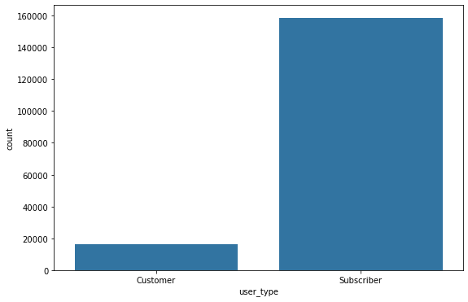

```python
# plotting graph
plt.figure(figsize=[9,6]);
sb.countplot(data=df_fordgobike,x='user_type',color=color);
```

## Observation

Here we could see that more subscribers used the service for the month

## Question

What is the member_gender spreading?

## Visualization

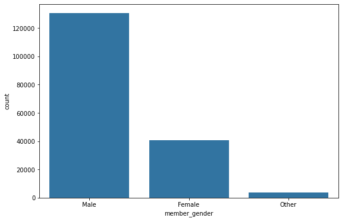

```python
order=df_fordgobike.member_gender.value_counts().index
# plotting graph
plt.figure(figsize=[9,6]);
sb.countplot(data=df_fordgobike,x='member_gender',color=color,order=order);
plt.show();
```

## Observation

The bar plot depicts that the gender "Male" makes more use of the services as compared to "Female" gender and of course the least gender "Other"

## Question

The most Rendevous by user is on which day?

## Visualization

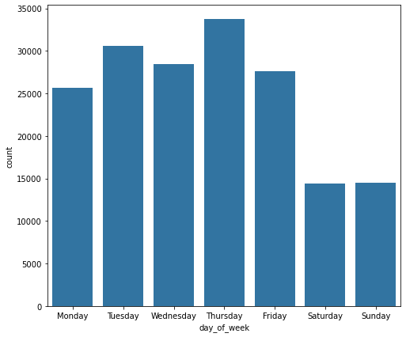

```python
plt.figure(figsize=[8,7])
color=sb.color_palette()[0]
days=['Monday','Tuesday','Wednesday','Thursday','Friday','Saturday','Sunday']
day_order=pd.api.types.CategoricalDtype(ordered=True,categories=days)
df_fordgobike.day_of_week=df_fordgobike.day_of_week.astype(day_order)
# order=df_fordgobike.day_of_week.value_counts().index
sb.countplot(data=df_fordgobike,x='day_of_week',color=color,);
```

## Observation

The plot depicts that majority of the users have rendevous on Thursday while weekends take the least days

## Question

What is the spreading of users by time of the day?

## Visualization

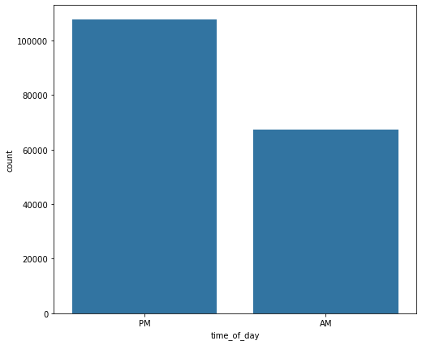

```python
plt.figure(figsize=[8,7])
sb.countplot(data=df_fordgobike,x='time_of_day',color=color);
plt.show();
```

## Observation

The barplot shows that afternoons and evenings have more rendevous as compared to the mornings

## Question

What are people likeness for bike share for all service?

## Visualization

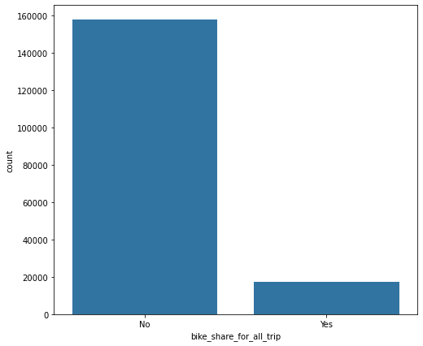

```python
plt.figure(figsize=[8,7])
sb.countplot(data=df_fordgobike,x='bike_share_for_all_trip',color=color);
plt.show();
```

## Observation

The bike share for all trip is not liked by many people as such it did not enjoy good patronage .

### Discussion on the distribution(s) of variable(s) of interest.

I extracted from the start_time variable AM or PM and save it in (time_of_day) as new variable;this was done to enable me explore the time_of_day that had more rendevous by users. Start_time was prefreably used as against end_time as it reliably showed the high percentage of spreading of users of bike in the afternoon and evening as compared to mornings

### unusual distributions and operations performed on the data to tidy, adjust, or change the form of the data

A qualitative variable age was created from the user_age variable .This was done to give me a better insights about the relationships. Missing data was dropped from the dataset whoes result affected the columns-end_station_id,member_gender,member_birth_year.About 0.1% of the data came from 197 cases in the end_station_id variable while about 4.5% of the data came from member_gender and member_birth_year. However, after effective cleaning of the dataset, all variables now have 174952 instances while user_age replaced member_birth_year .

## Bivariate Exploration

I want to investigate the pairwise affiliation between features in the data. To this end, what is the affiliation between age and duration minutes?

## Visualization

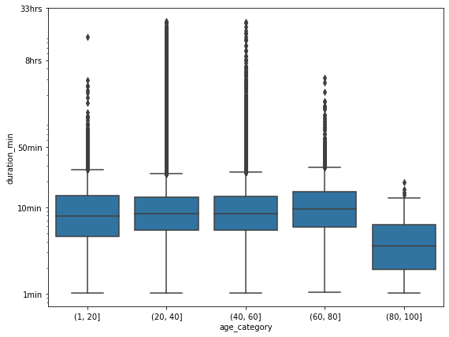

```python
plt.figure(figsize=[9,7])
color=sb.color_palette()[0]
sb.boxplot(data=df_fordgobike,x='age_category',y='duration_min',color=color);
plt.yscale('log')
y_loc=[1,10,50,500,2000]
y_labels=['1min','10min','50min','8hrs','33hrs']
plt.yticks(y_loc,y_labels);
```

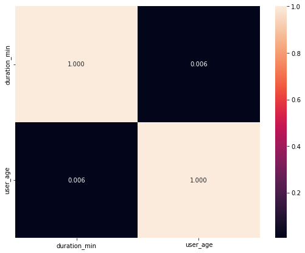

```python
# correlating plot
plt.figure(figsize=[9,7])
time_and_age= ['duration_min','user_age']
sb.heatmap(df_fordgobike[time_and_age].corr(),annot=True,fmt='.3f',cmap='rocket');
plt.show();
```

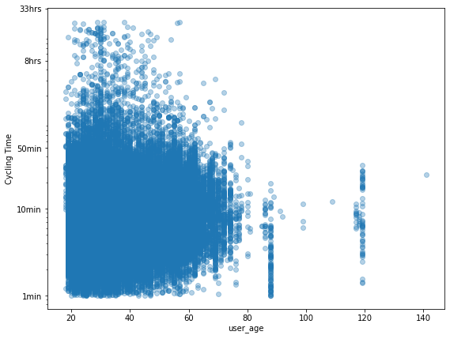

```python
# correlating scatter plot
plt.figure(figsize=[9,7])
sb.regplot(data=df_fordgobike,x='user_age',y='duration_min',fit_reg=False,scatter_kws={'alpha':1/3});
plt.yscale('log')
plt.yticks(y_loc,y_labels);
plt.ylabel('Cycling Time');
```

## Observation

The company would generate lots of revenue from this age range(20 to 60) cycling activities as such all hands must be on deck so as to avoid downtime in their operations.

## Question

What is the spreading of one category of people group by a second category?

## Visualization

### user_type grouped by age_category

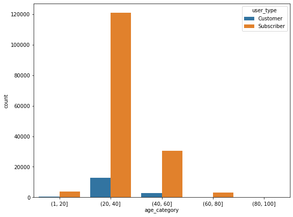

```python
plt.figure(figsize=[9,7])
sb.countplot(data=df_fordgobike,x='age_category',hue='user_type');
```

### user_type grouped by gender

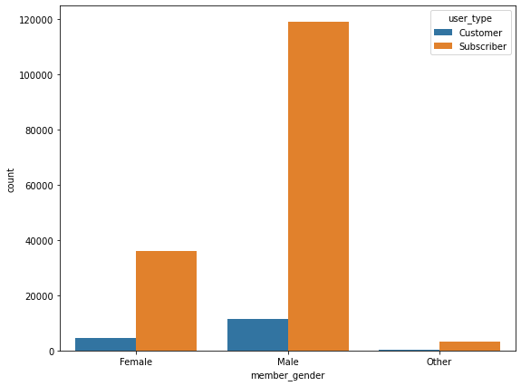

```python
plt.figure(figsize=[9,7])
sb.countplot(data=df_fordgobike,x='member_gender',hue='user_type');
```

### age_category grouped by member_gender

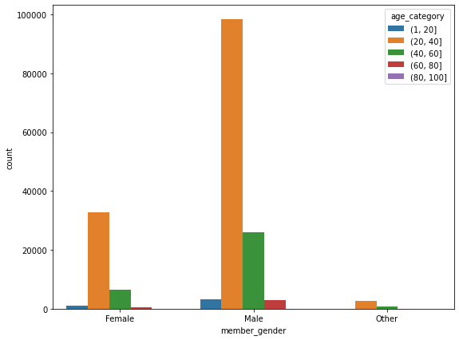

```python
plt.figure(figsize=[9,7])
sb.countplot(data=df_fordgobike,x='member_gender',hue='age_category');
```

## Observation

There is no explicit group that shows that some age category are more of a subscriber than customers as all groups are correspondingly spread over numerous age categorys. Furthermore, trend picked from the data is that people with age 20-40,male,subscribers rendvous more with regrads to the fordgo biking service.

Male subscribers between ages (20 to 40) should be given more considerations by the company as this makes the largest poll that uses their services

## Question

Does any affiliation exist between duration_min and user_type?

## Visualization

Measurement visualization

```python
df_fordgobike.groupby('user_type',)['duration_min'].mean()
```

```
user_type
Customer      21.844268
Subscriber    10.675855
Name: duration_min, dtype: float64
```

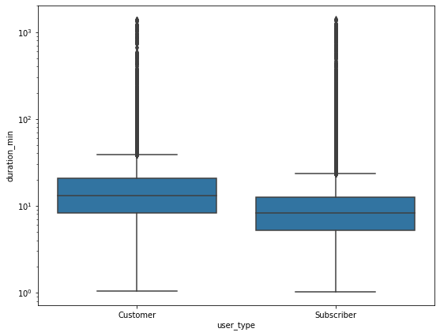

```python
# plotting boxplot
plt.figure(figsize=[9,7])
default_color=sb.color_palette()[0]
m=sb.boxplot(data=df_fordgobike,x='user_type',y='duration_min',color=default_color);
plt.yscale('log');
plt.show();
```

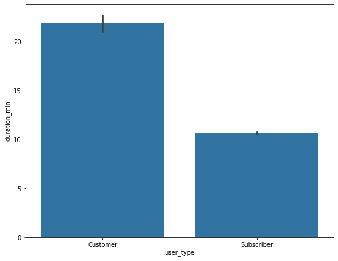

```python
# testing duration_min mean for subscriber Vs customer
plt.figure(figsize=[9,7])
sb.barplot(data=df_fordgobike,x='user_type',y='duration_min',color=color);
plt.show();
```

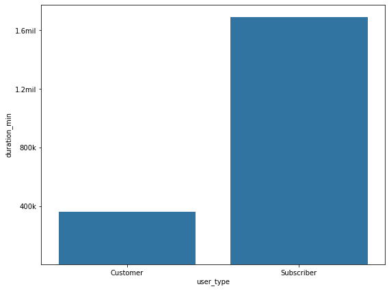

```python
# create total duration minutes
# for this analysis,generate new data frame
new_total=df_fordgobike.groupby('user_type')['duration_min'].sum().reset_index()
# plotting bar graph
plt.figure(figsize=[9,7])
sb.barplot(data=new_total,x='user_type',y='duration_min',color=color);
yloc=[400000,800000,1200000,1600000]
y_labels=['400k','800k','1.2mil','1.6mil']
plt.yticks(yloc,y_labels);
plt.show();
```

## Observation

On the average the customers category have more cycling time while the subscriber category are numerous in number. Furthermore, the trend from the data shows customer category have greater mean and median although they are less in number.

Once more, the company should give good considerations to not only the subscribers category but the customers as well since the customers show substantial rendevous with respect to average time spent while using the company's services.

## Question

What is the total cycling duration for Men Vs Women Vs Others

## Visualization

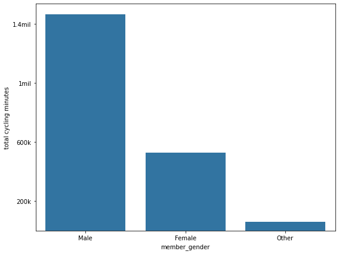

```python
new_total=df_fordgobike.groupby('member_gender')['duration_min'].sum().reset_index()
order=df_fordgobike.member_gender.value_counts().index
# plotting bar graph
plt.figure(figsize=[9,7])
sb.barplot(data=new_total,x='member_gender',y='duration_min',color=color,order=order);
yloc=[200000,600000,1000000,1400000]
y_labels=['200k','600k','1mil','1.4mil']
plt.yticks(yloc,y_labels);
plt.ylabel('total cycling minutes')
plt.show();
```

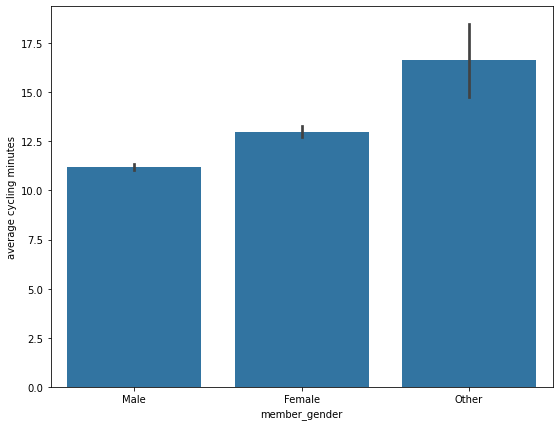

```python
# plotting bar graph for average cycling minutes
plt.figure(figsize=[9,7])
sb.barplot(data=df_fordgobike,x='member_gender',y='duration_min',color=color,order=order);
plt.ylabel('average cycling minutes');
plt.show();
```

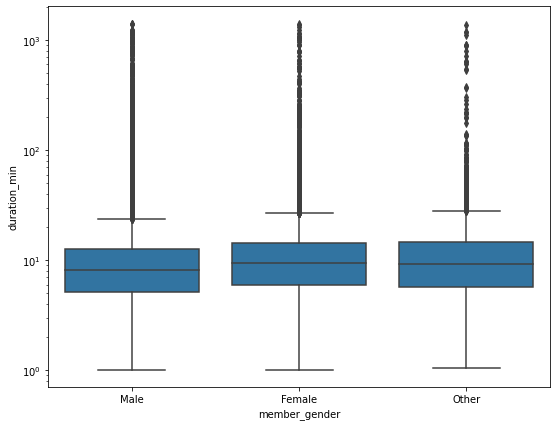

```python
# plotting boxplot
plt.figure(figsize=[9,7])
m=sb.boxplot(data=df_fordgobike,x='member_gender',y='duration_min',color=color,order=order);
plt.yscale('log');
```

## Observation

Findings here shows that member_gender variable trail the trend as that of user_type as groups with minor counts incline to larger means and medians values. This trend implies that these groups are of paramount importance to the company as well

## Question

Across dissimilar days of the week, what is the total spreading of gender?

## Visualization

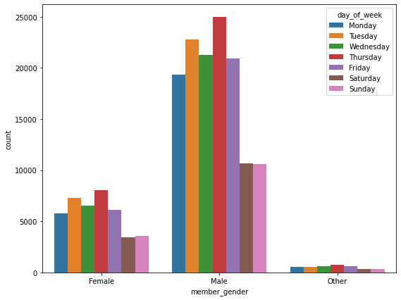

```python
plt.figure(figsize=[9,7])
# plotting bar graph
sb.countplot(data=df_fordgobike,x='member_gender',hue='day_of_week');
plt.show();
```

## Observation

As expected, the male folks with their large number still took the lead in rendevous with respect to all days of the week. This is followed by female and the least with other.

## Question

With non interest feature in data, is there any astonishing correlation?

## Visualization

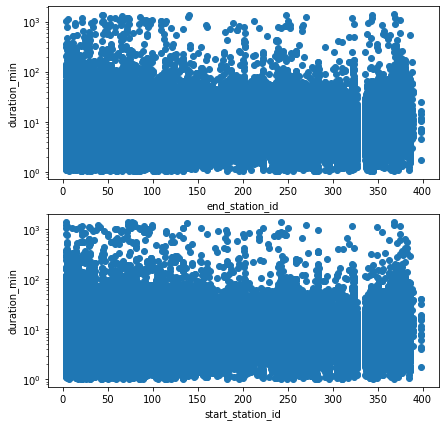

```python
# examining for corr between duration_min,end_station_id,start_station_id
def plot_corr(data,var1,var2,):
    variables=[var1,var2,]
    fig, ax=plt.subplots(nrows=2,figsize=[7,7])

    for i in range(len(variables)):
        var=variables[i]
        ax[i].scatter(data=data,x=var,y='duration_min')
        ax[i].set_yscale('log')
        ax[i].set_xlabel(var);
        ax[i].set_ylabel('duration_min')

plot_corr(df_fordgobike,'end_station_id','start_station_id')
```

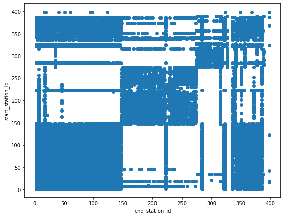

```python
# inspecting for affiliation between end_station_id and start_station_id
plt.figure(figsize=[9,7])
# plotting scatter plot
plt.scatter(data=df_fordgobike,x='end_station_id',y='start_station_id');
plt.xlabel('end_station_id');
plt.ylabel('start_station_id');
plt.show();
```

## Observation

No correlation could be established between the variables duration_min,end_station_id and start_station_id as the plot depicts somewhat square-like shape

### The relationships you observed in this part of the investigation.

The question posed to this dataset was answered based on the insights gathered from the analysis thus far. I observed a huge rendevous with the company services by users that spanned (20 to 40)years old over other age category. Based on the yardstick (numbers), subscriber type user had extra rendevous than customer type user although further examination showed that irrespective of smaller number of customer type user, they also had rendevous with regards to average cycling duration. Comparable trend was also evident in member_gender column as smaller amount of other gender had many mean cycling duration.This implies that on the average, the age range of (20 to 40)years old subscriber male had shorter cycling time but higher total cycling duration time. Thus the subscriber male often rendevous in shorter tours spending less amount of time with the company services

### Did you observe any interesting relationships between the other features (not the main feature(s) of interest)?

There was no noticeable correlation between duration_min and other features but an intriguing plot emerged from end_station_id and start_station_id that looked somewhat like a squared SCAN CODE design. I see this as outlier for future investigation

## Multivariate Exploration

The major thing i want to discover in this part of the investigation is how the categorical measure of quality link with duration_min

## Question

How duration_min play into the affiliation between user_type and member_gender variables

## Visualization

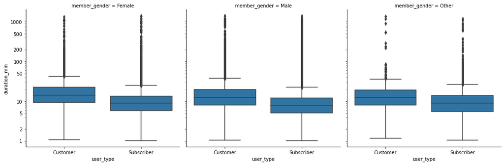

```python
g=sb.FacetGrid(data=df_fordgobike,col='member_gender',size=5)
g.map(sb.boxplot,'user_type','duration_min');
plt.yscale('log')
y_loc=[1,2,5,10,50,100,200,500,1000]
y_ticks=('{}'.format(v) for v in y_loc)
plt.yticks(y_loc,y_ticks);
```

## Observation

The plot above depicts that subscriber type have smaller median values with higher numbers as compared to customer type.

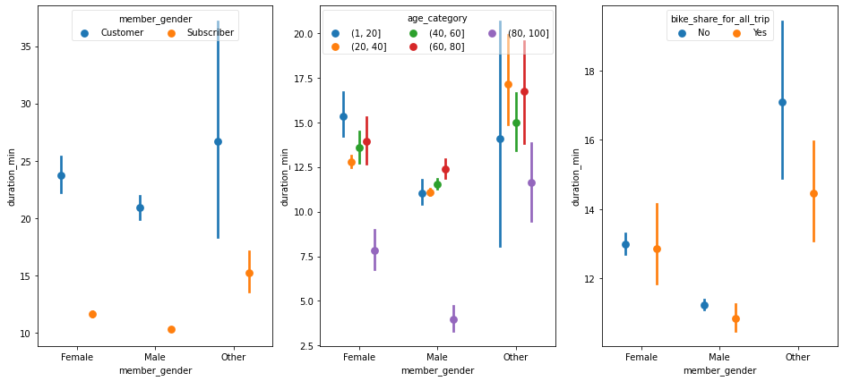

```python
plt.figure(figsize=[16,7])

order=df_fordgobike.member_gender.value_counts().index
plt.subplot(1,3,1)

sb.pointplot(data = df_fordgobike, x = 'member_gender', y = 'duration_min', hue = 'user_type', linestyles = '', dodge = 0.4);
plt.legend(loc = 9, ncol = 3, framealpha = 0.5, title = 'member_gender');
plt.subplot(1,3,2)
sb.pointplot(data = df_fordgobike, x = 'member_gender', y = 'duration_min', hue = 'age_category', linestyles = '', dodge = 0.4);
plt.legend(loc = 9, ncol = 3, framealpha = 0.5, title = 'age_category');
plt.subplot(1,3,3)
sb.pointplot(data = df_fordgobike, x= 'member_gender', y = 'duration_min', hue = 'bike_share_for_all_trip', linestyles = '', dodge = 0.4);
plt.legend(loc = 9, ncol = 3, framealpha = 0.5, title= 'bike_share_for_all_trip');
plt.show();
```

## Observation

i. Overall leaning of groups with smaller numbers and higher duration minutes on average

ii. "Other gender" had high variance in spreading

iii. As expected there was smaller average duration minutes with age category of (80 to 100)years

iv. Subscriber between (20 to 40)years had low variance because they tend not to use the bike share for all service

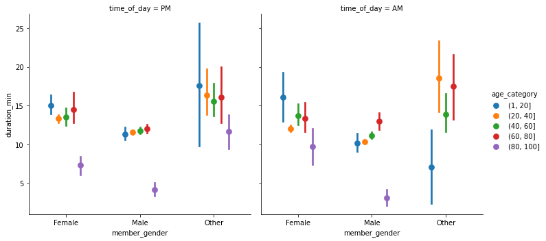

```python
sb.catplot(data=df_fordgobike, x='member_gender', y='duration_min', hue='age_category', kind='point', dodge=0.4, col='time_of_day',linestyles='');
plt.show();
```

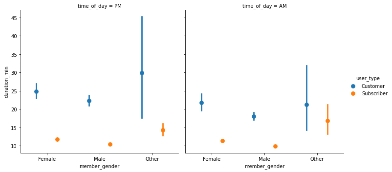

```python
sb.catplot(data=df_fordgobike, x='member_gender', y='duration_min', hue='user_type', kind='point', dodge=0.4, col='time_of_day',linestyles='');
plt.show();
```

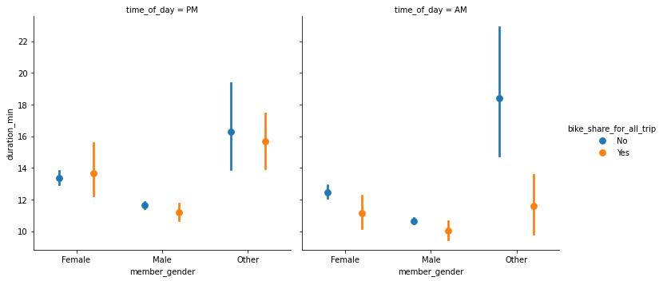

```python
sb.catplot(data=df_fordgobike, x='member_gender', y='duration_min', hue='bike_share_for_all_trip', kind='point', dodge=0.4, col='time_of_day',linestyles='');
plt.show();
```

## Observation

i. For "Other" gender group, there is high variance in the mornings and evenings as expected

ii. Male subscribers in the age category of (20 to 40)years that do not use the bike_share_for_all services generates more revenue than the others.

iii. The "Other" gender subscriber type that uses the bike_share_for_all services generates the least revenue for the company.

### Relationships observed in this part of the investigation.

The insights generated from the affiliation between duration_minutes and the other qualitative variables led to trends in groups that relates more with the Ford Go Bike service company as depicted in the plots with conclusions as per below:

i. For "Other" gender group, there is high variance in the mornings and evenings as expected

ii. Male subscribers in the age category of (20 to 40)years that do not use the bike_share_for_all services generates more revenue than the others.

iii. The "Other" gender subscriber type that uses the bike_share_for_all services generates the least revenue for the company

## Conclusions

. The "Male" gender makes the most of the Ford Gobike services followed by "Female" and the "Others"

. Thursdays have the highest peak of riders while weekends have the least riders

. Afternoons and evenings is the time of the day that has heavy traffic of riders which implies that most rendevous happens at this time of the day

. The age range of (20 to 60)years are heavily involved in the cycling activities. This goes a long way to let us know that the bike company generates a lot of revenue from this age category.

. Subscriber type are numerous in number while customer type are lesser number although on the average, the customer category have more cycling time.